# 제 10강: 선형모형 1

데이터과학 입문

원중호

서울대학교 통계학과

April 2026

## 시작하기 전에

다음의 패키지가 설치되어 있지 않으면 설치한다.

- R
- Python

```r
# install.packages("MASS")
# install.packages("tidyverse")
library(MASS)
library(tidyverse)
```

```python
import session_info
import numpy as np
import pandas as pd
import polars as pl
from plotnine import *
import matplotlib.pyplot as plt
import statsmodels.api as sm
import statsmodels.formula.api as smf
from statsmodels.stats.anova import anova_lm
from patsy import dmatrix
from patsy.contrasts import Helmert
from patsy.contrasts import Treatment
from patsy.contrasts import Poly
from numpy.linalg import qr
from scipy.linalg import svd

session_info.show()
```

```
-----
matplotlib          3.10.8
numpy               2.4.3
pandas              3.0.1
patsy               1.0.2
plotnine            0.15.3
polars              1.38.1
scipy               1.17.1
session_info        1.0.0
statsmodels         0.14.6
-----
Python 3.12.12 | packaged by conda-forge | (main, Jan 27 2026, 00:04:03) [Clang 19.1.7 ]
macOS-26.2-arm64-arm-64bit
-----
Session information updated at 2026-04-29 08:30
```

## 선형 모형 (Venables and Ripley Ch. 6)

- 고전 통계학의 핵심
- 많은 통계 실무의 기초
- 다수의 현대적 모형 및 분석 기법은 선형 모형을 위해 개발된 방법론을 기반으로 함

# An Analysis of Covariance Example

## Whiteside 자료

1960년대에 영국 건축 연구소(UK Building Research Station)의 데릭 화이트사이드(Derek Whiteside)가 수집한 자료 ([Hand et al., 1994](https://doi.org/10.1201/9780429246579)).

- 잉글랜드 남동부에 있는 화이트사이드의 집에서 캐비티 벽 단열재를 설치하기 전과 후의 두 번의 “난방 시즌” 동안 주간 가스 소비량과 평균 외부 기온을 기록
- 실험 목적: 단열재가 가스 소비에 미치는 영향을 평가
- R
- Python

```r
as_tibble(whiteside)
```

```
# A tibble: 56 × 3
   Insul   Temp   Gas
   <fct>  <dbl> <dbl>
 1 Before  -0.8   7.2
 2 Before  -0.7   6.9
 3 Before   0.4   6.4
 4 Before   2.5   6
 5 Before   2.9   5.8
 6 Before   3.2   5.8
 7 Before   3.6   5.6
 8 Before   3.9   4.7
 9 Before   4.2   5.8
10 Before   4.3   5.2
# ℹ 46 more rows
```

```python
url = 'https://raw.githubusercontent.com/vincentarelbundock/Rdatasets/master/csv/MASS/whiteside.csv'
whiteside = pl.read_csv(url)
whiteside = whiteside.with_columns(
    pl.col("Insul").cast(pl.Categorical)
)
whiteside.head()
```

shape: (5, 4)

| rownames i64 | Insul cat | Temp f64 | Gas f64 |
| --- | --- | --- | --- |
| 1 | "Before" | -0.8 | 7.2 |
| 2 | "Before" | -0.7 | 6.9 |
| 3 | "Before" | 0.4 | 6.4 |
| 4 | "Before" | 2.5 | 6.0 |
| 5 | "Before" | 2.9 | 5.8 |

- `Insul`: `Before`와 `After`의 두 수준을 갖는 요인 변수
- `Temp`: 섭씨 단위의 주간 평균 외부 기온
- `Gas`: 1,000 입방피트 단위의 주간 가스 소비량

먼저 자료를 단열재 설치 전과 후로 나누어 두 개의 패널에 최소제곱 직선을 함께 그려 보자.

- R
- Python

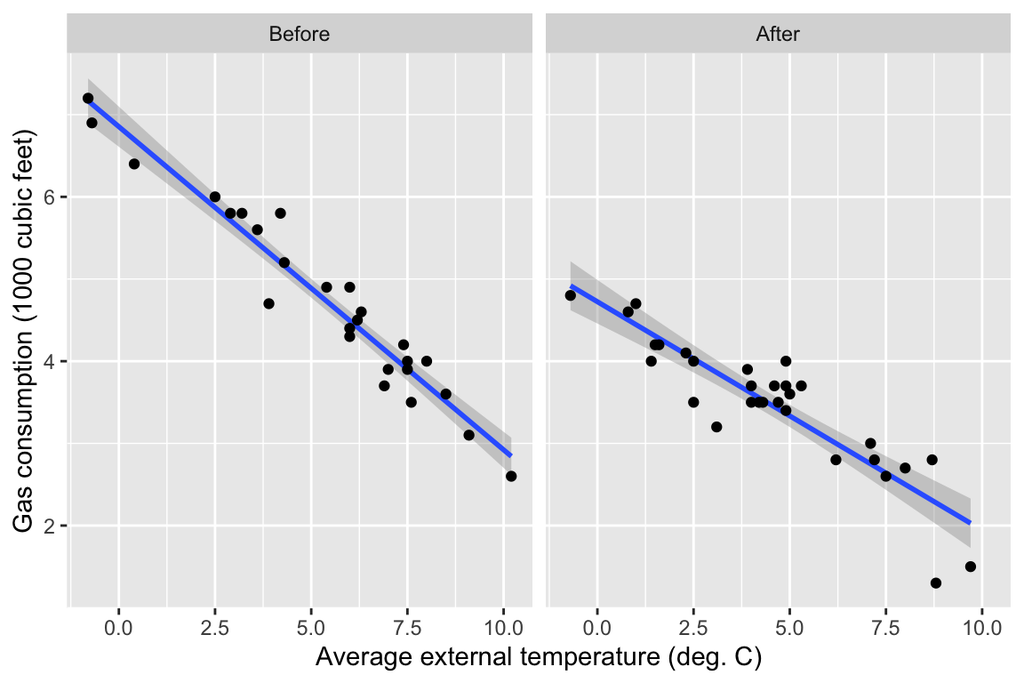

```r
ggplot(data=MASS::whiteside, aes(x=Temp, y=Gas), facets=~Insul) +
    stat_smooth(method = "lm") +
    geom_point() +
    facet_wrap(~ Insul) +
    labs(x = "Average external temperature (deg. C)",
         y = "Gas consumption (1000 cubic feet)")
```

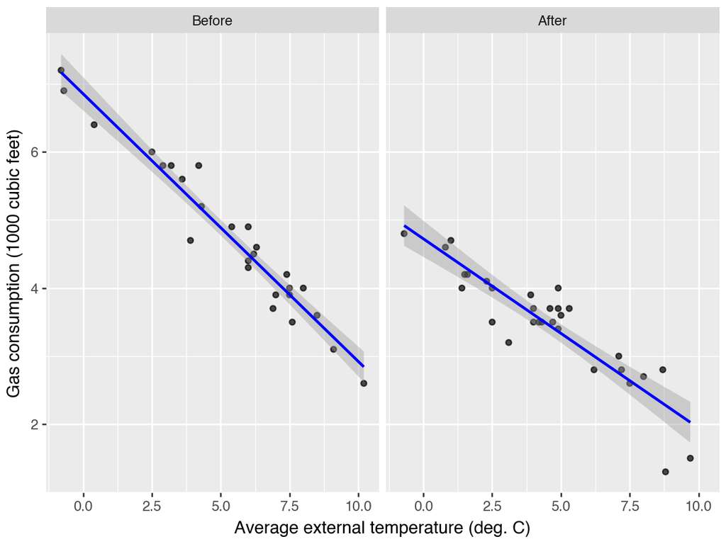

```python
(
    ggplot(whiteside, aes(x="Temp", y="Gas"))
    + geom_point(alpha=0.7)
    + stat_smooth(method="lm", color="blue")
    + facet_wrap("~Insul")
    + labs(
        x="Average external temperature (deg. C)",
        y="Gas consumption (1000 cubic feet)"
    )
).show()
```

- 주어진 온도 범위 내에서는 직선 모형이 적절한 것으로 보인다.
- 그래프로 미루어 볼 때, 단열재가 동일한 외부 온도에서 가스 소비량을 줄이지만 직선의 기울기, 즉 외부 온도가 떨어질수록 가스 소비량이 증가하는 속도에도 영향을 미치는 것으로 보인다.

## 선형모형과 `lm()`

이러한 문제를 정량적으로 탐색하기 위해 `lm`을 기본 함수로 하는 선형 모형을 적용한다.

- R
- Python

```r
lm(formula, data, subset, weights, na.action)
```

```python
smf.ols(formula, data, subset,).fit()
```

- `formula`: [윌킨슨-로저스 모형 공식](https://doi.org/10.2307/2346786) (유일한 필수 인수)
- `data`: 데이터 프레임 (선택 사항)
- `weights`: 양의 가중치 벡터 (균등하지 않은 가중치가 필요한 경우)
- `subset`: 사용할 데이터의 하위 집합을 지정하는 인덱스 벡터 (기본적으로 모든 항목이 사용됨)
- `na.action`: 결측치를 처리하는 방법을 지정하는 함수 (기본값은 `na.omit`, 즉 생략. 적합치에 `NA`가 포함되어야 하는 경우는 `na.exclude` 사용)

그래프의 직선을 각각 적합하기 위해 아래와 같이 `lm`을 사용할 수 있다.

- R
- Python

```r
gasB <- lm(Gas ~ Temp, data = MASS::whiteside, subset = Insul == "Before")
# gasB <- lm(Gas ~ 1+Temp, data = MASS::whiteside, subset = Insul == "Before") # same result as above
gasA <- update(gasB, subset = Insul == "After")  # modify the fitted model
```

```python
df_before = whiteside.filter(pl.col("Insul") == "Before").to_pandas()
formula = "Gas ~ Temp"
gasB = smf.ols(formula, data=df_before).fit()

df_after = whiteside.filter(pl.col("Insul") == "After").to_pandas()
gasA = smf.ols(formula, data=df_after).fit()

print("Before Insulation Slope:", gasB.params["Temp"])
```

```
Before Insulation Slope: -0.3932388222464556
```

```python
print("After Insulation Slope:", gasA.params["Temp"])
```

```
After Insulation Slope: -0.277934951787222
```

적합된 모형 객체는 `lm` 클래스에 속한다. 객체에 대한 추가 작업을 수행하는 generic 함수는 다음과 같다.

- `print`: 간단한 출력
- `summary`: 통상적인 회귀분석 결과 출력,
- `coef` (or `coefficients`): 회귀계수 추출
- `resid` (or `residuals`): 잔차 추출
- `fitted` (or `fitted.values`): 적합치 추출
- `deviance`: 잔차제곱합 추출
- `anova`: 분산표를 순차적 분석 또는 여러 계층적 모형을 비교
- `predict`: 새로운 데이터에 대한 평균 예측, 선택적으로 표준 오차 포함
- `plot`: 진단 플롯

## `lm` 객체

### 분석 결과 요약

- R
- Python

```r
summary(gasB) # p. 142
```

```
## Coefficients:
##             Estimate Std. Error t value Pr(>|t|)
## (Intercept)  6.85383    0.11842   57.88   <2e-16 ***
## Temp        -0.39324    0.01959  -20.08   <2e-16 ***
## ---
##
## Residual standard error: 0.2813 on 24 degrees of freedom
```

```python
gasB.summary()
```

OLS Regression Results

| Dep. Variable: | Gas | R-squared: | 0.944 |
| --- | --- | --- | --- |
| Model: | OLS | Adj. R-squared: | 0.941 |
| Method: | Least Squares | F-statistic: | 403.1 |
| Date: | Wed, 29 Apr 2026 | Prob (F-statistic): | 1.64e-16 |
| Time: | 08:30:41 | Log-Likelihood: | -2.8783 |
| No. Observations: | 26 | AIC: | 9.757 |
| Df Residuals: | 24 | BIC: | 12.27 |
| Df Model: | 1 |  |  |
| Covariance Type: | nonrobust |  |  |

|  | coef | std err | t | P>\|t\| | [0.025 | 0.975] |
| --- | --- | --- | --- | --- | --- | --- |
| Intercept | 6.8538 | 0.118 | 57.876 | 0.000 | 6.609 | 7.098 |
| Temp | -0.3932 | 0.020 | -20.078 | 0.000 | -0.434 | -0.353 |

| Omnibus: | 0.296 | Durbin-Watson: | 2.420 |
| --- | --- | --- | --- |
| Prob(Omnibus): | 0.862 | Jarque-Bera (JB): | 0.164 |
| Skew: | -0.177 | Prob(JB): | 0.921 |
| Kurtosis: | 2.839 | Cond. No. | 13.3 |

Notes:  
[1] Standard Errors assume that the covariance matrix of the errors is correctly specified.

- R
- Python

```r
summary(gasA)
```

```
## Coefficients:
##             Estimate Std. Error t value Pr(>|t|)
## (Intercept)  4.72385    0.12974   36.41  < 2e-16 ***
## Temp        -0.27793    0.02518  -11.04 1.05e-11 ***
## ---
##
## Residual standard error: 0.3548 on 28 degrees of freedom
```

```python
gasA.summary()
```

OLS Regression Results

| Dep. Variable: | Gas | R-squared: | 0.813 |
| --- | --- | --- | --- |
| Model: | OLS | Adj. R-squared: | 0.806 |
| Method: | Least Squares | F-statistic: | 121.8 |
| Date: | Wed, 29 Apr 2026 | Prob (F-statistic): | 1.05e-11 |
| Time: | 08:30:41 | Log-Likelihood: | -10.451 |
| No. Observations: | 30 | AIC: | 24.90 |
| Df Residuals: | 28 | BIC: | 27.70 |
| Df Model: | 1 |  |  |
| Covariance Type: | nonrobust |  |  |

|  | coef | std err | t | P>\|t\| | [0.025 | 0.975] |
| --- | --- | --- | --- | --- | --- | --- |
| Intercept | 4.7238 | 0.130 | 36.410 | 0.000 | 4.458 | 4.990 |
| Temp | -0.2779 | 0.025 | -11.036 | 0.000 | -0.330 | -0.226 |

| Omnibus: | 5.755 | Durbin-Watson: | 1.545 |
| --- | --- | --- | --- |
| Prob(Omnibus): | 0.056 | Jarque-Bera (JB): | 4.028 |
| Skew: | -0.800 | Prob(JB): | 0.133 |
| Kurtosis: | 3.815 | Cond. No. | 10.6 |

Notes:  
[1] Standard Errors assume that the covariance matrix of the errors is correctly specified.

### 표본 분산

- R
- Python

```r
(varB <- deviance(gasB) / gasB$df.resid)  # direct calculation
```

```
[1] 0.07914867
```

```r
(varB <- summary(gasB)$sigma^2)           # alternative
```

```
[1] 0.07914867
```

```python
varB_direct = gasB.ssr / gasB.df_resid
varB_alt = gasB.mse_resid

print(f"Residual Variance (Direct): {varB_direct}")
```

```
Residual Variance (Direct): 0.07914867320974193
```

```python
print(f"Residual Variance (MSE):    {varB_alt}")
```

```
Residual Variance (MSE):    0.07914867320974193
```

- 두 회귀 모형을 하나의 `lm` 객체에 적합:
- R
- Python

```r
gasBA <- lm(Gas ~ Insul / Temp - 1, data = MASS::whiteside)
summary(gasBA)
```

```
Call:
lm(formula = Gas ~ Insul/Temp - 1, data = MASS::whiteside)

Residuals:
     Min       1Q   Median       3Q      Max
-0.97802 -0.18011  0.03757  0.20930  0.63803

Coefficients:
                 Estimate Std. Error t value Pr(>|t|)
InsulBefore       6.85383    0.13596   50.41   <2e-16 ***
InsulAfter        4.72385    0.11810   40.00   <2e-16 ***
InsulBefore:Temp -0.39324    0.02249  -17.49   <2e-16 ***
InsulAfter:Temp  -0.27793    0.02292  -12.12   <2e-16 ***
---
Signif. codes:  0 '***' 0.001 '**' 0.01 '*' 0.05 '.' 0.1 ' ' 1

Residual standard error: 0.323 on 52 degrees of freedom
Multiple R-squared:  0.9946,    Adjusted R-squared:  0.9942
F-statistic:  2391 on 4 and 52 DF,  p-value: < 2.2e-16
```

```python
gasBA = smf.ols('Gas ~ Insul / Temp - 1', data=whiteside.to_pandas()).fit()
print(gasBA.summary())
```

```
                            OLS Regression Results
==============================================================================
Dep. Variable:                    Gas   R-squared:                       0.928
Model:                            OLS   Adj. R-squared:                  0.924
Method:                 Least Squares   F-statistic:                     222.3
Date:                Wed, 29 Apr 2026   Prob (F-statistic):           1.23e-29
Time:                        08:30:41   Log-Likelihood:                -14.100
No. Observations:                  56   AIC:                             36.20
Df Residuals:                      52   BIC:                             44.30
Df Model:                           3
Covariance Type:            nonrobust
======================================================================================
                         coef    std err          t      P>|t|      [0.025      0.975]
--------------------------------------------------------------------------------------
Insul[Before]          6.8538      0.136     50.409      0.000       6.581       7.127
Insul[After]           4.7238      0.118     40.000      0.000       4.487       4.961
Insul[Before]:Temp    -0.3932      0.022    -17.487      0.000      -0.438      -0.348
Insul[After]:Temp     -0.2779      0.023    -12.124      0.000      -0.324      -0.232
==============================================================================
Omnibus:                        6.016   Durbin-Watson:                   1.854
Prob(Omnibus):                  0.049   Jarque-Bera (JB):                4.998
Skew:                          -0.626   Prob(JB):                       0.0822
Kurtosis:                       3.757   Cond. No.                         13.3
==============================================================================

Notes:
[1] Standard Errors assume that the covariance matrix of the errors is correctly specified.
```

- `a`가 요인인 `a/x` 형식의 모형공식 항은 “`a`의 각 수준에서 `1 + x` 꼴의 개별 회귀 모형”으로 생각할 수 있다.
  - 또는 `a + a:x`의 모형공식으로 이해할 수도 있다.
- 추정치는 동일하지만 표준 오차가 달라진 것을 볼 수 있다. 이는 `gasBA`가 분산을 풀링해서 추정하기 때문이다.

### 이차식 회귀

- R
- Python

```r
gasQ <- lm(Gas ~ Insul/(Temp + I(Temp^2)) - 1, data = MASS::whiteside)
summary(gasQ)$coef
```

```
                          Estimate  Std. Error   t value     Pr(>|t|)
InsulBefore            6.759215179 0.150786777 44.826312 4.854615e-42
InsulAfter             4.496373920 0.160667904 27.985514 3.302572e-32
InsulBefore:Temp      -0.317658735 0.062965170 -5.044991 6.362323e-06
InsulAfter:Temp       -0.137901603 0.073058019 -1.887563 6.489554e-02
InsulBefore:I(Temp^2) -0.008472572 0.006624737 -1.278930 2.068259e-01
InsulAfter:I(Temp^2)  -0.014979455 0.007447107 -2.011446 4.968398e-02
```

```python
gasQ = smf.ols('Gas ~ Insul/(Temp + I(Temp**2)) - 1', data=whiteside.to_pandas()).fit()
print(gasQ.params)
```

```
Insul[Before]                 6.759215
Insul[After]                  4.496374
Insul[Before]:Temp           -0.317659
Insul[After]:Temp            -0.137902
Insul[Before]:I(Temp ** 2)   -0.008473
Insul[After]:I(Temp ** 2)    -0.014979
dtype: float64
```

- ‘identity’ 함수 `I()`는 산술적 의미 그대로 인수를 평가
- 개별 회귀 계수를 보면 `After` 그룹에만 2차항이 필요할 가능성이 있지만 그 증거가 압도적이지 않음.
- 단순성을 이유로 개별 선형회귀 모형을 유지

### 분산분석

- 더 간단한 모형으로 기울기가 같은 회귀모형을 생각할 수 있다.
- 이 모형을 적합하고 `anova` 함수를 사용하여 수준별 기울기를 갖는 회귀 모형 내에서 검정할 수 있다. (왜 그런가?)
- R
- Python

```r
# MASS p. 143
gasPR <- lm(Gas ~ Insul + Temp, data = MASS::whiteside)
anova(gasPR, gasBA)
```

```
Analysis of Variance Table

Model 1: Gas ~ Insul + Temp
Model 2: Gas ~ Insul/Temp - 1
  Res.Df    RSS Df Sum of Sq      F    Pr(>F)
1     53 6.7704
2     52 5.4252  1    1.3451 12.893 0.0007307 ***
---
Signif. codes:  0 '***' 0.001 '**' 0.01 '*' 0.05 '.' 0.1 ' ' 1
```

```python
gasPR = sm.OLS.from_formula('Gas ~ Insul + Temp', data=whiteside.to_pandas()).fit()

print(anova_lm(gasPR, gasBA))
```

```
   df_resid       ssr  df_diff   ss_diff          F    Pr(>F)
0      53.0  6.770382      0.0       NaN        NaN       NaN
1      52.0  5.425247      1.0  1.345135  12.892872  0.000731
```

- 분산분석 결과는 수준별 기울기가 실제로 필요하다는 것을 보여준다.
- 수준별 기울기를 갖는 선형모형을 다른 방식으로 기술하면 분석분석을 보다 간단하고 유익하게 수행할 수 있다.
- R
- Python

```r
gasBA1 <- lm(Gas ~ Insul * Temp, data = MASS::whiteside)
summary(gasBA1)$coef
```

```
                  Estimate Std. Error    t value     Pr(>|t|)
(Intercept)      6.8538277 0.13596397  50.409146 7.997414e-46
InsulAfter      -2.1299780 0.18009172 -11.827185 2.315921e-16
Temp            -0.3932388 0.02248703 -17.487358 1.976009e-23
InsulAfter:Temp  0.1153039 0.03211212   3.590665 7.306852e-04
```

```python
gasBA1 = smf.ols('Gas ~ Insul * Temp', data=whiteside.to_pandas()).fit()
print(gasBA1.summary().tables[1])
```

```
=======================================================================================
                          coef    std err          t      P>|t|      [0.025      0.975]
---------------------------------------------------------------------------------------
Intercept               6.8538      0.136     50.409      0.000       6.581       7.127
Insul[T.After]         -2.1300      0.180    -11.827      0.000      -2.491      -1.769
Temp                   -0.3932      0.022    -17.487      0.000      -0.438      -0.348
Insul[T.After]:Temp     0.1153      0.032      3.591      0.001       0.051       0.180
=======================================================================================
```

# 모형 공식과 모형 행렬

## 모형 공식

선형 모형은 응답 벡터 $\boldsymbol{y}$와 설명 변수 행렬 또는 모형 행렬 $X$로 결정된다.

모형 공식은 좌변에 응답변수를, 우변에는 특정 규칙에 따라 모형 행렬을 생성하는 방법에 대한 지시사항을 적는다.

### 예제: 3변수 다중선형모형

모형 공식

```
    y ~ x1 + x2 + x3
```

대수적 기술

$$y_i = \beta_0 + \beta_1 x_{i1} + \beta_2 x_{i2} + \beta_3 x_{i3} + \epsilon_i,
\quad
i= 1, 2, \dotsc, n$$

모형 행렬

$$X = [\mathbf{1} ~ \mathbf{x}_1 ~ \mathbf{x}_2 ~ \mathbf{x}_3]$$

절편 $\beta_0$는 모형공식에서 암묵적으로 가정된다 (`y ~ 1 + x1 + x2 + x3`).

```
    y ~ x1 + x2 + x3 - 1
```

로 절편을 제거할 수 있다.

### 예제: 1원배치 모형

설명변수 `a`가 $k$개 수준을 갖는 범주형 변수 (`factor`).

대수적 기술

$$y_{ij} = \mu + \alpha_j + \epsilon_{ij},
\quad
i=1,2,\dotsc,n_j;
~
j=1,2,\dotsc, k;
~
n = \sum_j n_j$$

벡터형식 및 모형행렬

$$\begin{split}
\mathbf{y} &= X\boldsymbol{\beta} + \boldsymbol{\epsilon},
\\
\boldsymbol{\beta} &= [\mu, \alpha_1, \alpha_2, \dotsc, \alpha_k]^T = [\mu, \boldsymbol{\alpha}^T]^T,
\\
\mathbf{y} &= [y_{11}, \dotsc, y_{n_1,1}, \dotsc, y_{1k}, \dotsc, y_{n_k,k}]^T,
\\
X &= [\mathbf{1} ~ X_a],
\end{split}$$

- $X_a$는 $n\times k$ 행렬로 각 **행**이 `a`의 소속 수준에 해당하는 열에만 1이 있는 벡터(dummy variable, one-hot vector)로 구성된 이진행렬 ($n = \underset{j=1} { \stackrel{k}{\sum} } n_j$).
- 예: $n_1=2$, $n_2=1=n_3$, $k=3$
  $$X_a = \begin{bmatrix} 1 & 0 & 0 \\ 1 & 0 & 0 \\ 0 & 1 & 0 \\ 0 & 0 & 1 \end{bmatrix}$$

**일반형**

$$X_a = \begin{bmatrix} \mathbf{1}_{n_1} & O & \cdots & O \\ O & \mathbf{1}_{n_2} & \ddots & \vdots \\ \vdots & \ddots & \ddots & O \\ O & \cdots & O & \mathbf{1}_{n_k}\end{bmatrix}$$

- 모형행렬 $X$ ($X_a$ 아님)의 랭크는 얼마인가?
- 이 모형은 식별가능한가?

#### 식별가능 모형 1: 제약식

$$y_{ij} = \alpha_j + \epsilon_{ij},
\quad
i=1,2,\dotsc,n_j;
~
j=1,2,\dotsc, k$$
즉, $\beta_0 = \mu = 0$으로 제약. 벡터형식: $\mathbf{e}_1^T \boldsymbol{\beta} = 0$; $\mathbf{e}_1 = [1, 0, \dotsc, 0]^T$.

- 모형행렬? 랭크?
- 모형 공식: `y ~ a - 1`
- R
- Python

```r
    set.seed(2026-03-01)
    dat <- data.frame(a = factor(rep(1:3, each=3)),
                      y = rnorm(9, rep(2:4, each=3), 0.1))
    mod <- lm(y ~ a - 1, data = dat)
    coef(mod)
```

```
      a1       a2       a3
1.960977 2.844129 3.998939
```

```python
# np.random.seed(20260301)
# a_values = np.repeat([1, 2, 3], 3)
# y_values = np.random.normal(loc=np.repeat([2, 3, 4], 3), scale=0.1, size=9)
# dat = pl.DataFrame({
#    "a": pl.Series(a_values).cast(pl.String).cast(pl.Categorical),
#    "y": y_values
#})
dat = r.dat
mod = smf.ols("y ~ a - 1", data=dat).fit()
print(mod.params)
```

```
a[1]    1.960977
a[2]    2.844129
a[3]    3.998939
dtype: float64
```

- R
- Python

```r
model.matrix(mod)
```

```
  a1 a2 a3
1  1  0  0
2  1  0  0
3  1  0  0
4  0  1  0
5  0  1  0
6  0  1  0
7  0  0  1
8  0  0  1
9  0  0  1
attr(,"assign")
[1] 1 1 1
attr(,"contrasts")
attr(,"contrasts")$a
[1] "contr.treatment"
```

```python
# 1. Get the design matrix as a NumPy array
design_matrix_array = mod.model.exog
# 2. To see it with column names (like the R output)
design_matrix_df = pl.DataFrame(
    design_matrix_array,
    schema=mod.model.data.param_names
)
print(design_matrix_df)
```

```
shape: (9, 3)
┌──────┬──────┬──────┐
│ a[1] ┆ a[2] ┆ a[3] │
│ ---  ┆ ---  ┆ ---  │
│ f64  ┆ f64  ┆ f64  │
╞══════╪══════╪══════╡
│ 1.0  ┆ 0.0  ┆ 0.0  │
│ 1.0  ┆ 0.0  ┆ 0.0  │
│ 1.0  ┆ 0.0  ┆ 0.0  │
│ 0.0  ┆ 1.0  ┆ 0.0  │
│ 0.0  ┆ 1.0  ┆ 0.0  │
│ 0.0  ┆ 1.0  ┆ 0.0  │
│ 0.0  ┆ 0.0  ┆ 1.0  │
│ 0.0  ┆ 0.0  ┆ 1.0  │
│ 0.0  ┆ 0.0  ┆ 1.0  │
└──────┴──────┴──────┘
```

#### 식별가능 모형 2: 부호화 행렬

- 알려진 사실 $X_a\mathbf{1}_k = \mathbf{1}_n$로부터 (왜 그런가?)
  $$\begin{split}
  [\mathbf{1}_n~X_a]\begin{bmatrix} \mu \\ \boldsymbol{\alpha} \end{bmatrix}
  &= \mathbf{1}_n\mu + X_a\boldsymbol{\alpha}
  \\
  &= X_a\mathbf{1}_k\mu + X_a\boldsymbol{\alpha}
  = [\mathbf{1}_n~X_a]\begin{bmatrix} 0 \\ \mathbf{1}_k\mu + \boldsymbol{\alpha} \end{bmatrix}
  \end{split}$$
  임을 알 수 있다.
- $\mu$의 값이 임의임도 알 수 있다.
- 차원 $k \times (k-1)$인 최대랭크(full rank) 행렬 $C_a$에 대해 정방행렬 $[\mathbf{1}_k~C_a]$가 정칙(nonsingular)이라고 가정하면
  $$\mathbf{1}_k\mu + \boldsymbol{\alpha} = [\mathbf{1}_k~C_a]\begin{bmatrix} \mu^* \\ \boldsymbol{\alpha}^* \end{bmatrix}$$
  인 $\mu^*$, $\boldsymbol{\alpha}^*$가 항상 존재한다.
- 따라서,
  $$\begin{split}
  [\mathbf{1}_n~X_a]\begin{bmatrix} 0 \\ \mathbf{1}_k\mu + \boldsymbol{\alpha} \end{bmatrix}
  &= X_a(\mathbf{1}_k\mu + \boldsymbol{\alpha})
  \\
  &= X_a[\mathbf{1}_k~C_a]\begin{bmatrix} \mu^* \\ \boldsymbol{\alpha}^* \end{bmatrix}
  = [\mathbf{1}_n ~ X_a C_a]\begin{bmatrix} \mu^* \\ \boldsymbol{\alpha}^* \end{bmatrix}
  .
  \end{split}$$
- 이때 $[\mathbf{1}_n ~ X_a C_a] = X_a[\mathbf{1}_k~C_a]$은 최대랭크 행렬이므로 (왜 그런가?) 이를 새로운 모형행렬로 삼으면 $\mu^*$, $\boldsymbol{\alpha}^*$은 최소제곱법에 의해 유일하게 결정된다.
- 위 조건을 만족하는 행렬 $C_a$를 부호화행렬(coding matrix)이라 부른다. 모형에서 $\mu$는 임의이므로 $\mu = \mu^*$로 두면
  $$\boldsymbol{\alpha} = C_a\boldsymbol{\alpha}^*$$
  가 된다.

## 부호화 행렬의 종류

### 처리 부호화 (treatment coding)

R의 기본 부호화. 항상 $\alpha_1 = 0$으로 한다. 이렇게 하면 수준 1이 다른 모든 수준을 비교하는 표준 수준으로 취급된다.

- R
- Python

```r
mod_treatment <- lm(y ~ a, data=dat)
model.matrix(mod_treatment)
```

```
  (Intercept) a2 a3
1           1  0  0
2           1  0  0
3           1  0  0
4           1  1  0
5           1  1  0
6           1  1  0
7           1  0  1
8           1  0  1
9           1  0  1
attr(,"assign")
[1] 0 1 1
attr(,"contrasts")
attr(,"contrasts")$a
[1] "contr.treatment"
```

```python
mod_treatment = smf.ols("y ~ a", data=dat).fit()
design_matrix_treatment = pl.DataFrame(
    mod_treatment.model.exog,
    schema=mod_treatment.model.data.param_names
)
print(design_matrix_treatment)
```

```
shape: (9, 3)
┌───────────┬────────┬────────┐
│ Intercept ┆ a[T.2] ┆ a[T.3] │
│ ---       ┆ ---    ┆ ---    │
│ f64       ┆ f64    ┆ f64    │
╞═══════════╪════════╪════════╡
│ 1.0       ┆ 0.0    ┆ 0.0    │
│ 1.0       ┆ 0.0    ┆ 0.0    │
│ 1.0       ┆ 0.0    ┆ 0.0    │
│ 1.0       ┆ 1.0    ┆ 0.0    │
│ 1.0       ┆ 1.0    ┆ 0.0    │
│ 1.0       ┆ 1.0    ┆ 0.0    │
│ 1.0       ┆ 0.0    ┆ 1.0    │
│ 1.0       ┆ 0.0    ┆ 1.0    │
│ 1.0       ┆ 0.0    ┆ 1.0    │
└───────────┴────────┴────────┘
```

- R
- Python

```r
(alph.star <- coef(mod_treatment)) # mu^* = (Intercept)
```

```
(Intercept)          a2          a3
  1.9609770   0.8831515   2.0379625
```

```r
(Ca <- contr.treatment(length(levels(dat$a))))
```

```
  2 3
1 0 0
2 1 0
3 0 1
```

```r
(alph <- Ca %*% alph.star[-1])    # letting $mu = mu^*$
```

```
       [,1]
1 0.0000000
2 0.8831515
3 2.0379625
```

```python
# 1. Extract the coefficients (alpha.star)
alph_star = mod_treatment.params
print("Coefficients (alpha.star):\n", alph_star)
```

```
Coefficients (alpha.star):
 Intercept    1.960977
a[T.2]       0.883152
a[T.3]       2.037962
dtype: float64
```

```python
# 2. Generate the Treatment Contrast Matrix (Ca)
# In Python, we specify the levels (3) and use the Treatment object
levels = [1, 2, 3]
contrast_obj = Treatment().code_with_intercept(levels)
Ca = contrast_obj.matrix[:, 1:]
print("Contrast Matrix (Ca):\n", Ca)
```

```
Contrast Matrix (Ca):
 [[0. 0.]
 [1. 0.]
 [0. 1.]]
```

```python
# 3. Calculate the offsets (alph)
alph = Ca @ alph_star[1:].values
print("Calculated Offsets (alph):\n", alph)
```

```
Calculated Offsets (alph):
 [0.         0.88315151 2.03796247]
```

### 헬메르트 부호화 (Helmert coding)

S-plus의 기본 부호화. 각 열의 합이 0이 되도록 한다.

- R
- Python

```r
mod_helmert <- lm(y ~ a, data=dat, contrasts = list(a = "contr.helmert"))
(alph.star <- coef(mod_helmert))
```

```
(Intercept)          a1          a2
  2.9346817   0.4415758   0.5321289
```

```r
(Ca <- contr.helmert(length(levels(dat$a))))
```

```
  [,1] [,2]
1   -1   -1
2    1   -1
3    0    2
```

```r
(alph <- Ca %*% alph.star[-1])   # letting $mu = mu^*$
```

```
         [,1]
1 -0.97370466
2 -0.09055315
3  1.06425781
```

```r
sum(alph)   # numerically zero. why?
```

```
[1] 0
```

```python
from patsy.contrasts import Helmert

# In Python/Patsy, we use the C() function in the formula to specify the coding
mod_helmert = smf.ols("y ~ C(a, Helmert)", data=dat).fit()
# 1. Extract coefficients
alph_star = mod_helmert.params
print("Coefficients (alpha.star):\n", alph_star)
```

```
Coefficients (alpha.star):
 Intercept             2.934682
C(a, Helmert)[H.2]    0.441576
C(a, Helmert)[H.3]    0.532129
dtype: float64
```

```python
# 2. Generate Helmert Contrast Matrix
levels = [1, 2, 3]
Ca = Helmert().code_without_intercept(levels).matrix
print("Helmert Contrast Matrix (Ca):\n", Ca)
```

```
Helmert Contrast Matrix (Ca):
 [[-1. -1.]
 [ 1. -1.]
 [ 0.  2.]]
```

```python
# 3. Calculate the effects (alph)
alph = Ca @ alph_star[1:].values
print("Calculated Effects (alph):\n", alph)
```

```
Calculated Effects (alph):
 [-0.97370466 -0.09055315  1.06425781]
```

```python
# 4. Sum of effects
print("Sum of alph:", np.sum(alph))
```

```
Sum of alph: 0.0
```

### 직교다항식 부호화 (orthogonal polynomial coding)

R의 **순서형 변수**에 대한 기본 부호화.

- R
- Python

```r
dat$b <- as.ordered(dat$a)
mod_poly <- lm(y ~ b, data=dat)
(alph.star <- coef(mod_poly))
```

```
(Intercept)         b.L         b.Q
  2.9346817   1.4410571   0.1109045
```

```r
(Ca <- contr.poly(length(levels(dat$b))))
```

```
                .L         .Q
[1,] -7.071068e-01  0.4082483
[2,] -9.681035e-17 -0.8164966
[3,]  7.071068e-01  0.4082483
```

```r
(alph <- Ca %*% alph.star[-1])     # letting $mu = mu^*$
```

```
            [,1]
[1,] -0.97370466
[2,] -0.09055315
[3,]  1.06425781
```

```r
sum(alph)   # numerically zero
```

```
[1] -6.661338e-16
```

```python
from patsy.contrasts import Poly

# Ensure 'a' is an ordered categorical
dat['b'] = pd.Categorical(dat['a'], ordered=True)
# Fit the Polynomial Model
mod_poly = smf.ols("y ~ C(b, Poly)", data=dat).fit()

# 1. Extract coefficients
alph_star = mod_poly.params
print("Coefficients (alpha.star):\n", alph_star)
```

```
Coefficients (alpha.star):
 Intercept               2.934682
C(b, Poly).Linear       1.441057
C(b, Poly).Quadratic    0.110905
dtype: float64
```

```python
# 2. Generate Polynomial Contrast Matrix (Ca)
levels = [1, 2, 3]
Ca = Poly().code_without_intercept(levels).matrix
print("Polynomial Contrast Matrix (Ca):\n", Ca)
```

```
Polynomial Contrast Matrix (Ca):
 [[-7.07106781e-01  4.08248290e-01]
 [-4.43378006e-17 -8.16496581e-01]
 [ 7.07106781e-01  4.08248290e-01]]
```

```python
# 3. Calculate the effects (alph)
alph = Ca @ alph_star[1:].values
print("Calculated Effects (alph):\n", alph)
```

```
Calculated Effects (alph):
 [-0.97370466 -0.09055315  1.06425781]
```

```python
# 4. Sum check
print("Sum of alph:", np.sum(alph))
```

```
Sum of alph: 0.0
```

## 모수 해석

- 원모수 $\mu$, $\alpha$ (식별불가능)와 축소된 모수 $\mu^*$, $\alpha^*$ (식별가능) 사이의 관계
  $$\begin{bmatrix} \mu^* \\ \boldsymbol{\alpha}^* \end{bmatrix}
  =
  [\mathbf{1}_k~C_a]^{-1}
  (\mathbf{1}_k\mu + \boldsymbol{\alpha})$$
  를 상기하자.
- $D = [\mathbf{1}_k~C_a]^{-1}$로 놓고 $D$의 행을 $\mathbf{d}_0^T, \mathbf{d}_1^T, \dotsc, \mathbf{d}_{k-1}^T$라 하면
  $$I_k = D[\mathbf{1}_k~C_a]
  =
  \begin{bmatrix} \mathbf{d}_0^T \\ \mathbf{d}_1^T \\ \vdots \\ \mathbf{d}_{k-1}^T \end{bmatrix}
  [\mathbf{1}_k~C_a]
  =
  \begin{bmatrix}
  \mathbf{d}_0^T\mathbf{1}_k & \mathbf{d}_0^TC_a \\
  \mathbf{d}_1^T\mathbf{1}_k & \mathbf{d}_1^TC_a \\
  \vdots & \vdots \\
  \mathbf{d}_{k-1}^T\mathbf{1}_k & \mathbf{d}_{k-1}^TC_a
  \end{bmatrix}$$
  이므로
  $$\mathbf{d}_0^T C_a = \mathbf{0}^T,
  \quad
  \mathbf{d}_0^T\mathbf{1}_k = 1,
  \quad
  \mathbf{d}_i^T\mathbf{1}_k = 0,
  ~
  i=1, \dotsc, k-1$$
  임을 알 수 있다.
- 이제 $D$를 복호화행렬이라 부르자.
- 어떤 벡터 $\mathbf{v}$가 $\mathbf{v}^T\mathbf{1} = 1$이면 평균벡터, $\mathbf{v}^T\mathbf{1} = 0$이면 대조벡터라고 부르기로 하면, $\mathbf{d}_0$은 평균벡터, $\mathbf{d}_1, \dotsc, \mathbf{d}_{k-1}$은 대조벡터임을 알 수 있다.
- 역으로 $k\times k$ 정칙행렬 $D$를 첫번째 행이 평균벡터, 나머지 행이 대조벡터가 되도록 고르면 그 역행렬 $D^{-1}$은 적당한 부호화행렬 $C_a$에 대해 $D^{-1} = [\mathbf{1}_k~ C_a]$가 된다. (왜 그런가?)
- 따라서 부호화행렬 $C_a$의 기술과 복호화행렬 $D$의 기술은 동등하다.

이제
$$\small
\begin{bmatrix} \mu^* \\ \alpha^*_1 \\ \vdots \\ \alpha^*_{k-1} \end{bmatrix}
=
\begin{bmatrix} \mu^* \\ \boldsymbol{\alpha}^* \end{bmatrix}
=
D(\mathbf{1}_k\mu + \boldsymbol{\alpha})
=
\begin{bmatrix} \mu + \mathbf{d}_0^T\boldsymbol{\alpha} \\ \mathbf{d}_1^T\boldsymbol{\alpha} \\ \vdots \\
\mathbf{d}_{k-1}^T\boldsymbol{\alpha} \end{bmatrix}$$
이 되어 $\mu^*$은 원모수 성분 $(\mu+\alpha_1, \dotsc, \mu+\alpha_k)$의 $\mathbf{d}_0^T = (d_{01}, \dotsc, d_{0k})$에 의한 가중평균임을, $\alpha^*_i$는 $\boldsymbol{\alpha}$의 $\mathbf{d}_i$에 의한 대조(contrast)임을 알 수 있다. 즉,
$$\alpha^*_i = \mathbf{d}_i^T\boldsymbol{\alpha}, \quad i=1, \dotsc, k-1$$
으로 모수 사이의 관계를 해석할 수 있다.

- 이때 $\mu$는 임의이므로 $\mu = \mu^*$으로 놓으면 가중평균 $\mathbf{d}_0^T\boldsymbol{\alpha} = 0$이 되어 이를 제약조건으로 두고 $(\mu, \boldsymbol{\alpha})$를 추정하면 추정값 $(\hat{\mu}, \hat{\boldsymbol{\alpha}})$이 유일하게 정해지고 $\widehat{\mu^*} = \hat{\mu}$, $\widehat{\alpha^*_i} = \mathbf{d}_i^T\hat{\boldsymbol{\alpha}}$가 된다.
- 따라서 부호화(복호화)행렬을 사용한 식별 기법은 제약식을 사용한 식별 기법의 특수한 경우임을 알 수 있다.

### 예: 처리 부호화 ($\alpha_{1}=0$으로 설정)

- R
- Python

```r
Ca <- contr.treatment(letters[1:5]) %>% print
```

```
  b c d e
a 0 0 0 0
b 1 0 0 0
c 0 1 0 0
d 0 0 1 0
e 0 0 0 1
```

```r
D <- solve(cbind(1, Ca)) %>% print
```

```
   a b c d e
   1 0 0 0 0
b -1 1 0 0 0
c -1 0 1 0 0
d -1 0 0 1 0
e -1 0 0 0 1
```

```python
from patsy.contrasts import Treatment

# 1. Generate the Treatment Contrast Matrix (Ca)
levels = ['a', 'b', 'c', 'd', 'e']
# Use code_without_intercept to get the 5x4 matrix of offsets
Ca = Treatment().code_without_intercept(levels).matrix
print("Contrast Matrix (Ca):\n", Ca)
```

```
Contrast Matrix (Ca):
 [[0. 0. 0. 0.]
 [1. 0. 0. 0.]
 [0. 1. 0. 0.]
 [0. 0. 1. 0.]
 [0. 0. 0. 1.]]
```

```python
# 2. Construct the full Design Matrix (X) and Invert it (D)
# Prepend a column of 1s for the Intercept
X = np.column_stack([np.ones(5), Ca])
D = np.linalg.inv(X)
print("Inverse Matrix (D):\n", D)
```

```
Inverse Matrix (D):
 [[ 1.  0.  0.  0.  0.]
 [-1.  1.  0.  0.  0.]
 [-1.  0.  1.  0.  0.]
 [-1.  0.  0.  1.  0.]
 [-1.  0.  0.  0.  1.]]
```

따라서 $\mu^* = \mu + \alpha_1$, $\alpha^*_1 = \alpha_2 - \alpha_1$, $\dotsc$, $\alpha_{k-1}^* = \alpha_k - \alpha_1$.

**Note**

왜 앞 식별가능모형1과 식별가능모형2–처리부호화 결과가 같았는가?

### 예: 헬메르트 부호화

- R
- Python

```r
Ca <- contr.helmert(letters[1:5]) %>% print
```

```
  [,1] [,2] [,3] [,4]
a   -1   -1   -1   -1
b    1   -1   -1   -1
c    0    2   -1   -1
d    0    0    3   -1
e    0    0    0    4
```

```r
D <- solve(cbind(1, Ca))
D %>% fractions %>% print
```

```
     a     b     c     d     e
[1,]   1/5   1/5   1/5   1/5   1/5
[2,]  -1/2   1/2     0     0     0
[3,]  -1/6  -1/6   1/3     0     0
[4,] -1/12 -1/12 -1/12   1/4     0
[5,] -1/20 -1/20 -1/20 -1/20   1/5
```

```python
from patsy.contrasts import Helmert
from fractions import Fraction

# 1. Generate the Helmert Contrast Matrix (Ca)
levels = ['a', 'b', 'c', 'd', 'e']
Ca = Helmert().code_without_intercept(levels).matrix
print("Helmert Contrast Matrix (Ca):\n", Ca)
```

```
Helmert Contrast Matrix (Ca):
 [[-1. -1. -1. -1.]
 [ 1. -1. -1. -1.]
 [ 0.  2. -1. -1.]
 [ 0.  0.  3. -1.]
 [ 0.  0.  0.  4.]]
```

```python
# 2. Construct the Design Matrix (X) and Invert (D)
X = np.column_stack([np.ones(5), Ca])
D = np.linalg.inv(X)

# 3. Print as fractions
def to_fraction(x):
    return str(Fraction(x).limit_denominator())
D_fractions = pd.DataFrame(D).map(to_fraction)
print("Inverse Matrix D (as Fractions):\n", D_fractions.to_string(index=False, header=False))
```

```
Inverse Matrix D (as Fractions):
   1/5   1/5   1/5   1/5 1/5
 -1/2   1/2     0     0   0
 -1/6  -1/6   1/3     0   0
-1/12 -1/12 -1/12   1/4   0
-1/20 -1/20 -1/20 -1/20 1/5
```

따라서
$$\small
\begin{split}
\mu^* &= \mu + \frac{1}{k}\sum_{j=1}^k \alpha_j
\\
\alpha^*_1 &= \frac{1}{2}(\alpha_2 - \alpha_1)
\\
\alpha^*_2 &= \frac{1}{3}(\alpha_3 - \frac{1}{2}\sum_{j=1}^2\alpha_j)
\\
& \vdots
\\
\alpha^*_{k-1} &= \frac{1}{k}(\alpha_k - \frac{1}{k-1}\sum_{j=1}^{k-1}\alpha_j)
\end{split}$$

**Note**

왜 앞 식별가능모형2–헬메르트부호화 결과에서 모수의 합이 (수치적으로) 0이었는가?

- 헬메르트 부호화행렬의 모든 열은 직교한다. 따라서 복호화행렬의 모든 행은 직교한다. (왜 그런가?)
- R
- Python

```r
t(Ca) %*% Ca
```

```
     [,1] [,2] [,3] [,4]
[1,]    2    0    0    0
[2,]    0    6    0    0
[3,]    0    0   12    0
[4,]    0    0    0   20
```

```python
print(np.dot(Ca.T, Ca))
```

```
[[ 2.  0.  0.  0.]
 [ 0.  6.  0.  0.]
 [ 0.  0. 12.  0.]
 [ 0.  0.  0. 20.]]
```

### 직교다항식 부호화

- $j$차 다항식 $p_j(x)$열이 다음을 만족:
  $$\begin{split}
  & \sum_{i=1}^n p_j^2(x_i) = 1, \quad j = 0, 1, \dotsc, q
  \\
  & \sum_{i=1}^n p_j(x_i)p_k(x_i) = 0, \quad j \neq k
  .
  \end{split}$$
- $x_i$의 열은 수직선에서 등간격으로 설정.
- R
- Python

```r
(Ca <- contr.poly(letters[1:5])) %>% zapsmall %>% print  # L=linear, Q=quadratic, etc.
```

```
             .L         .Q         .C         ^4
[1,] -0.6324555  0.5345225 -0.3162278  0.1195229
[2,] -0.3162278 -0.2672612  0.6324555 -0.4780914
[3,]  0.0000000 -0.5345225  0.0000000  0.7171372
[4,]  0.3162278 -0.2672612 -0.6324555 -0.4780914
[5,]  0.6324555  0.5345225  0.3162278  0.1195229
```

```r
poly(seq(-1, 1, length.out=5), degree=4) %>% zapsmall # coefficients of 4th-degree orthogonal polynomial (Kennedy & Gentle (1980, pp.343--4))
```

```
              1          2          3          4
[1,] -0.6324555  0.5345225 -0.3162278  0.1195229
[2,] -0.3162278 -0.2672612  0.6324555 -0.4780914
[3,]  0.0000000 -0.5345225  0.0000000  0.7171372
[4,]  0.3162278 -0.2672612 -0.6324555 -0.4780914
[5,]  0.6324555  0.5345225  0.3162278  0.1195229
attr(,"coefs")
attr(,"coefs")$alpha
[1] 4.440892e-17 1.776357e-16 6.344132e-17 1.387779e-16

attr(,"coefs")$norm2
[1] 1.00000000 5.00000000 2.50000000 0.87500000 0.22500000 0.03214286

attr(,"degree")
[1] 1 2 3 4
attr(,"class")
[1] "poly"   "matrix"
```

```python
from patsy.contrasts import Poly

Ca = Poly().code_without_intercept(levels=[1,2,3,4,5])
Ca = Ca.matrix
Ca_zapped = np.round(Ca, 10)
print("Categorical Polynomial Contrasts (Ca):\n", Ca_zapped)
```

```
Categorical Polynomial Contrasts (Ca):
 [[-0.63245553  0.53452248 -0.31622777  0.11952286]
 [-0.31622777 -0.26726124  0.63245553 -0.47809144]
 [ 0.         -0.53452248  0.          0.71713717]
 [ 0.31622777 -0.26726124 -0.63245553 -0.47809144]
 [ 0.63245553  0.53452248  0.31622777  0.11952286]]
```

```python
def manual_orthogonal_poly(x, degree):
    # Direct implementation of Kennedy & Gentle (1980, pp.343--4))
    x = np.array(x, dtype=float)
    n = len(x)

    x_centered = x - np.mean(x)

    P = np.zeros((n, degree + 1))
    alphas = np.zeros(degree + 1)
    betas = np.zeros(degree + 1)
    norms = np.zeros(degree + 1)

    # Degree 0: Constant term
    P[:, 0] = 1.0
    norms[0] = np.sqrt(np.sum(P[:, 0]**2))
    P[:, 0] /= norms[0] # Normalize P0

    for j in range(1, degree + 1):
        alphas[j] = np.dot(x_centered * P[:, j-1], P[:, j-1])

        if j > 1:
            # Based on the recurrence: P_j = (x - alpha)P_{j-1} - beta*P_{j-2}
            betas[j] = np.dot(x_centered * P[:, j-1], P[:, j-2])

        if j == 1:
            P[:, j] = (x_centered - alphas[j]) * P[:, j-1]
        else:
            P[:, j] = (x_centered - alphas[j]) * P[:, j-1] - betas[j] * P[:, j-2]

        norms[j] = np.sqrt(np.sum(P[:, j]**2))
        P[:, j] /= norms[j]

    return P[:, 1:], alphas[1:], betas[1:]

x_points = np.linspace(-1, 1, 5)
poly_matrix, a, b = manual_orthogonal_poly(x_points, 4)
print(poly_matrix)
```

```
[[-6.32455532e-01  5.34522484e-01 -3.16227766e-01  1.19522861e-01]
 [-3.16227766e-01 -2.67261242e-01  6.32455532e-01 -4.78091444e-01]
 [-3.98286449e-18 -5.34522484e-01 -2.35305013e-18  7.17137166e-01]
 [ 3.16227766e-01 -2.67261242e-01 -6.32455532e-01 -4.78091444e-01]
 [ 6.32455532e-01  5.34522484e-01  3.16227766e-01  1.19522861e-01]]
```

- R
- Python

```r
t(Ca) %*% Ca %>% fractions  # orthogonal?
```

```
   .L .Q .C ^4
.L 1  0  0  0
.Q 0  1  0  0
.C 0  0  1  0
^4 0  0  0  1
```

```r
D <- solve(cbind(1, Ca))
D %>% zapsmall %>% print
```

```
         [,1]       [,2]       [,3]       [,4]      [,5]
    0.2000000  0.2000000  0.2000000  0.2000000 0.2000000
.L -0.6324555 -0.3162278  0.0000000  0.3162278 0.6324555
.Q  0.5345225 -0.2672612 -0.5345225 -0.2672612 0.5345225
.C -0.3162278  0.6324555  0.0000000 -0.6324555 0.3162278
^4  0.1195229 -0.4780914  0.7171372 -0.4780914 0.1195229
```

```python
from patsy.contrasts import Poly
from fractions import Fraction

t_Ca_Ca = np.dot(Ca.T, Ca)
ortho_check_df = pd.DataFrame(t_Ca_Ca).map(lambda x: Fraction(x).limit_denominator())
print("Orthogonality Check (t(Ca) @ Ca):\n", ortho_check_df)
```

```
Orthogonality Check (t(Ca) @ Ca):
    0  1  2  3
0  1  0  0  0
1  0  1  0  0
2  0  0  1  0
3  0  0  0  1
```

```python
D = np.linalg.inv(np.hstack((np.ones((len(Ca), 1)), Ca)))
print("Inverse Matrix D (zapsmall):\n", np.round(D, 10))
```

```
Inverse Matrix D (zapsmall):
 [[ 0.2         0.2         0.2         0.2         0.2       ]
 [-0.63245553 -0.31622777 -0.          0.31622777  0.63245553]
 [ 0.53452248 -0.26726124 -0.53452248 -0.26726124  0.53452248]
 [-0.31622777  0.63245553  0.         -0.63245553  0.31622777]
 [ 0.11952286 -0.47809144  0.71713717 -0.47809144  0.11952286]]
```

따라서 $\mu^* = \mu + \frac{1}{k} \underset{j=1} { \stackrel{k}{\sum} } \alpha_j$.

**Note**

왜 앞 식별가능모형2–직교부호화 결과에서 모수의 합이 (수치적으로) 0이었는가?

## 2원 배치

- `a`, `b`가 각각 $r$, $s$개 수준을 갖는 범주형 변수(factor)라 하자.
- R
- Python

```r
dat2 <- dat  # copy
dat2$b <- factor(rep(1:3, 3))
```

```python
dat2 = dat.copy()
dat2['b'] = pd.Categorical(np.tile([1, 2, 3], 3))
```

### 2원 배치 가법 모형

```r
    # model formula
    y ~ a + b
```

- 대수적 기술
  $$y_{ijk} = \mu + \alpha_{i} + \beta_{j} + \epsilon_{ijk},$$
- 모형행렬 (랭크 부족)
  $$X = [\mathbf{1}, X_a, X_b],
  \quad
  \mathbf{y} = [\mathbf{1}, X_a, X_b] \begin{bmatrix} \mu \\ \boldsymbol{\alpha} \\ \boldsymbol{\beta} \end{bmatrix}$$
  여기서 $\mathbf{y}=(y_{ijk})$, $\boldsymbol{\alpha}=(\alpha_i)$, $\boldsymbol{\beta}=(\beta_j)$인 벡터.
- 축소모형의 모형행렬 : $X^*=[\mathbf{1}, X_a C_a, X_b C_b]$
- R
- Python

```r
model.matrix(y ~ a + b, data = dat2)
```

```
  (Intercept) a2 a3 b2 b3
1           1  0  0  0  0
2           1  0  0  1  0
3           1  0  0  0  1
4           1  1  0  0  0
5           1  1  0  1  0
6           1  1  0  0  1
7           1  0  1  0  0
8           1  0  1  1  0
9           1  0  1  0  1
attr(,"assign")
[1] 0 1 1 2 2
attr(,"contrasts")
attr(,"contrasts")$a
[1] "contr.treatment"

attr(,"contrasts")$b
[1] "contr.treatment"
```

```python
from patsy import dmatrix

print(dmatrix("a + b", data=dat2, return_type='dataframe'))
```

```
   Intercept  a[T.2]  a[T.3]  b[T.2]  b[T.3]
0        1.0     0.0     0.0     0.0     0.0
1        1.0     0.0     0.0     1.0     0.0
2        1.0     0.0     0.0     0.0     1.0
3        1.0     1.0     0.0     0.0     0.0
4        1.0     1.0     0.0     1.0     0.0
5        1.0     1.0     0.0     0.0     1.0
6        1.0     0.0     1.0     0.0     0.0
7        1.0     0.0     1.0     1.0     0.0
8        1.0     0.0     1.0     0.0     1.0
```

- R
- Python

```r
model.matrix(y ~ a, data=dat2)
```

```
  (Intercept) a2 a3
1           1  0  0
2           1  0  0
3           1  0  0
4           1  1  0
5           1  1  0
6           1  1  0
7           1  0  1
8           1  0  1
9           1  0  1
attr(,"assign")
[1] 0 1 1
attr(,"contrasts")
attr(,"contrasts")$a
[1] "contr.treatment"
```

```python
print(dmatrix("a", data=dat2, return_type='dataframe'))
```

```
   Intercept  a[T.2]  a[T.3]
0        1.0     0.0     0.0
1        1.0     0.0     0.0
2        1.0     0.0     0.0
3        1.0     1.0     0.0
4        1.0     1.0     0.0
5        1.0     1.0     0.0
6        1.0     0.0     1.0
7        1.0     0.0     1.0
8        1.0     0.0     1.0
```

- R
- Python

```r
model.matrix(y ~ b, data=dat2)
```

```
  (Intercept) b2 b3
1           1  0  0
2           1  1  0
3           1  0  1
4           1  0  0
5           1  1  0
6           1  0  1
7           1  0  0
8           1  1  0
9           1  0  1
attr(,"assign")
[1] 0 1 1
attr(,"contrasts")
attr(,"contrasts")$b
[1] "contr.treatment"
```

```python
print(dmatrix("b", data=dat2, return_type='dataframe'))
```

```
   Intercept  b[T.2]  b[T.3]
0        1.0     0.0     0.0
1        1.0     1.0     0.0
2        1.0     0.0     1.0
3        1.0     0.0     0.0
4        1.0     1.0     0.0
5        1.0     0.0     1.0
6        1.0     0.0     0.0
7        1.0     1.0     0.0
8        1.0     0.0     1.0
```

- 절편 항이 없는 축소모형(`y ~ a + b - 1`)의 모형 행렬: $X^*=[X_a ~ X_b C_b]$.
  - 이 경우 모형행렬 $X^*$는 `a`와 `b`에 대해 비대칭이고, 순서에 의존한다 (왜 그런가?)
- R
- Python

```r
model.matrix(y ~ a + b - 1, data = dat2)
```

```
  a1 a2 a3 b2 b3
1  1  0  0  0  0
2  1  0  0  1  0
3  1  0  0  0  1
4  0  1  0  0  0
5  0  1  0  1  0
6  0  1  0  0  1
7  0  0  1  0  0
8  0  0  1  1  0
9  0  0  1  0  1
attr(,"assign")
[1] 1 1 1 2 2
attr(,"contrasts")
attr(,"contrasts")$a
[1] "contr.treatment"

attr(,"contrasts")$b
[1] "contr.treatment"
```

```python
print(dmatrix("a + b - 1", data=dat2, return_type='dataframe'))
```

```
   a[1]  a[2]  a[3]  b[T.2]  b[T.3]
0   1.0   0.0   0.0     0.0     0.0
1   1.0   0.0   0.0     1.0     0.0
2   1.0   0.0   0.0     0.0     1.0
3   0.0   1.0   0.0     0.0     0.0
4   0.0   1.0   0.0     1.0     0.0
5   0.0   1.0   0.0     0.0     1.0
6   0.0   0.0   1.0     0.0     0.0
7   0.0   0.0   1.0     1.0     0.0
8   0.0   0.0   1.0     0.0     1.0
```

- R
- Python

```r
    model.matrix(y ~ b + a - 1, data = dat2)
```

```
  b1 b2 b3 a2 a3
1  1  0  0  0  0
2  0  1  0  0  0
3  0  0  1  0  0
4  1  0  0  1  0
5  0  1  0  1  0
6  0  0  1  1  0
7  1  0  0  0  1
8  0  1  0  0  1
9  0  0  1  0  1
attr(,"assign")
[1] 1 1 1 2 2
attr(,"contrasts")
attr(,"contrasts")$b
[1] "contr.treatment"

attr(,"contrasts")$a
[1] "contr.treatment"
```

```python
print(dmatrix("b + a - 1", data=dat2, return_type='dataframe'))
```

```
   b[1]  b[2]  b[3]  a[T.2]  a[T.3]
0   1.0   0.0   0.0     0.0     0.0
1   0.0   1.0   0.0     0.0     0.0
2   0.0   0.0   1.0     0.0     0.0
3   1.0   0.0   0.0     1.0     0.0
4   0.0   1.0   0.0     1.0     0.0
5   0.0   0.0   1.0     1.0     0.0
6   1.0   0.0   0.0     0.0     1.0
7   0.0   1.0   0.0     0.0     1.0
8   0.0   0.0   1.0     0.0     1.0
```

### 2원 배치 비가법모형

```r
    y ~ a + b + a:b
    # or
    y ~ a * b
```

- 이 모형은 $rs$ 수준을 갖는 1원배치 모형과 사실상 같다.
- 대수적 기술
  $$\begin{split}
  y_{ijk} &= \mu + \alpha_{i} + \beta_{j} + \gamma_{ij} + \epsilon_{ijk},
  \\
  &
  i=1,2,\dotsc,r;
  ~
  j=1,2,\dotsc, s;
  ~
  k=1,2,\dotsc, n_{ij}
  \end{split}$$
- 모형 행렬 : $X=[\mathbf{1}_n, X_a, X_b, X_a \odot X_b]$
  - 여기서 $A \odot B$는 $A$와 $B$의 한 열씩 뽑아 원소끼리 곱해서 새로운 열 하나를 만드는 연산.
    $$\begin{split}
    \mathbf{y} &= [\mathbf{1}_n, X_a, X_b, X_a\odot X_b]
    \begin{bmatrix} \mu \\ \boldsymbol{\alpha} \\ \boldsymbol{\beta} \\ \boldsymbol{\gamma} \end{bmatrix}
    \\
    &= \mathbf{1}_n\mu + X_a\boldsymbol{\alpha} + X_b\boldsymbol{\beta} + (X_a \odot X_b)\boldsymbol{\gamma}
    \end{split}$$
    여기서 $\boldsymbol{\gamma} = (\gamma_{ijk})$인 벡터.
  - $X_a \odot X_b$는 `a`와 `b`로 정의되는 하위범주에 대한 접속(incidence) 행렬.
- 축소모형의 모형 행렬 : $X^*=[\mathbf{1}, X_a C_a, X_b C_b, (X_a C_a)\odot (X_b C_b)]$
  - 열 수: $1 + (r-1) + (s-1) +(r-1)(s-1) = rs$
- R
- Python

```r
model.matrix(y ~ a * b, data = dat2)
```

```
  (Intercept) a2 a3 b2 b3 a2:b2 a3:b2 a2:b3 a3:b3
1           1  0  0  0  0     0     0     0     0
2           1  0  0  1  0     0     0     0     0
3           1  0  0  0  1     0     0     0     0
4           1  1  0  0  0     0     0     0     0
5           1  1  0  1  0     1     0     0     0
6           1  1  0  0  1     0     0     1     0
7           1  0  1  0  0     0     0     0     0
8           1  0  1  1  0     0     1     0     0
9           1  0  1  0  1     0     0     0     1
attr(,"assign")
[1] 0 1 1 2 2 3 3 3 3
attr(,"contrasts")
attr(,"contrasts")$a
[1] "contr.treatment"

attr(,"contrasts")$b
[1] "contr.treatment"
```

```python
print(dmatrix("a * b", data=dat2, return_type='dataframe'))
```

```
   Intercept  a[T.2]  a[T.3]  ...  a[T.3]:b[T.2]  a[T.2]:b[T.3]  a[T.3]:b[T.3]
0        1.0     0.0     0.0  ...            0.0            0.0            0.0
1        1.0     0.0     0.0  ...            0.0            0.0            0.0
2        1.0     0.0     0.0  ...            0.0            0.0            0.0
3        1.0     1.0     0.0  ...            0.0            0.0            0.0
4        1.0     1.0     0.0  ...            0.0            0.0            0.0
5        1.0     1.0     0.0  ...            0.0            1.0            0.0
6        1.0     0.0     1.0  ...            0.0            0.0            0.0
7        1.0     0.0     1.0  ...            1.0            0.0            0.0
8        1.0     0.0     1.0  ...            0.0            0.0            1.0

[9 rows x 9 columns]
```

- 다음과 비교하자.
- R
- Python

```r
X_star <- numeric()
XaCa <- model.matrix(y ~ a, data=dat2)[, -1]
XbCb <- model.matrix(y ~ b, data=dat2)[, -1]
for (i in seq_len(ncol(XbCb)))
    for (j in seq_len(ncol(XaCa)))
        X_star <- cbind(X_star, XbCb[, i] * XaCa[, j])
X_star
```

```
  [,1] [,2] [,3] [,4]
1    0    0    0    0
2    0    0    0    0
3    0    0    0    0
4    0    0    0    0
5    1    0    0    0
6    0    0    1    0
7    0    0    0    0
8    0    1    0    0
9    0    0    0    1
```

```python
XaCa = dmatrix("a - 1", data=dat2)[:, 1:]
XbCb = dmatrix("b - 1", data=dat2)[:, 1:]

X_star = pd.DataFrame()
for i in range(XbCb.shape[1]):
    for j in range(XaCa.shape[1]):
        X_star[f"XbCb_{i+1}_XaCa_{j+1}"] = XbCb[:, i] * XaCa[:, j]
print(X_star)
```

```
   XbCb_1_XaCa_1  XbCb_1_XaCa_2  XbCb_2_XaCa_1  XbCb_2_XaCa_2
0            0.0            0.0            0.0            0.0
1            0.0            0.0            0.0            0.0
2            0.0            0.0            0.0            0.0
3            0.0            0.0            0.0            0.0
4            1.0            0.0            0.0            0.0
5            0.0            0.0            1.0            0.0
6            0.0            0.0            0.0            0.0
7            0.0            1.0            0.0            0.0
8            0.0            0.0            0.0            1.0
```

- 다음을 상기하자.
  $$\begin{split}
  \mathbf{y} &= [\mathbf{1}, X_a C_a, X_b C_b, (X_a C_a)\odot (X_b C_b)]
  \begin{bmatrix} \mu \\ \boldsymbol{\alpha}^* \\ \boldsymbol{\beta}^* \\ \boldsymbol{\gamma}^* \end{bmatrix}
  \\
  &= \mathbf{1}_n\mu + X_aC_a\boldsymbol{\alpha}^* + X_bC_b\boldsymbol{\beta}^* + (X_aC_a \odot X_bC_b)\boldsymbol{\gamma}^*
  \end{split}$$
- 크로네커 곱 $\otimes$를 이용, $(X_a C_a)\odot (X_b C_b) = (X_a \odot X_b)(C_b \otimes C_a)$로 쓸 수 있고, 따라서 $\boldsymbol{\gamma} = (C_b \otimes C_a) \boldsymbol{\gamma}^*$.
  - $\boldsymbol{\gamma}$, $\boldsymbol{\gamma}^*$를 각각 $r \times s$ 행렬 $\Gamma$, $(r-1)\times (s-1)$ 행렬 $\Gamma^*$의 벡터 표현으로 이해하면 ($\boldsymbol{\gamma}=\operatorname{vec}(\Gamma)$), $\Gamma=C_a \Gamma^* C_{b}^T$가 성립한다. (왜 그런가?)
- 식별가능 제약은 $C_a^T$의 널벡터 $\mathbf{d}_a$ (즉 $\mathbf{d}_a^T C_a = \mathbf{0}^T$)와 $C_b^T$의 널벡터 $\mathbf{d}_b$에 대해
  $$\mathbf{d}_{a}^T \Gamma = \mathbf{0}^T,
  \quad
  \Gamma \mathbf{d}_{b} = \mathbf{0}$$
  으로 쓸 수 있다. (왜 그런가?)

### 무절편 2원배치 비가법모형 1

```r
    y ~ a * b - 1
    # or
    y ~ a + b + a:b - 1
```

- 대수적 기술
  $$\begin{split}
  y_{ijk} &= \alpha_{i} + \beta_{j} + \gamma_{ij} + \epsilon_{ijk},
  \\
  & i=1,2,\dotsc,r;
  ~
  j=1,2,\dotsc, s;
  ~
  k=1,2,\dotsc, n_{ij}
  \end{split}$$
- 모형 행렬 : $X^*=[X_a, X_b C_b, (X_a C_a) \odot (X_b C_b)]$
  - 교재의 결과(S-plus)와 다름
- R
- Python

```r
model.matrix(y ~ a * b - 1, data = dat2)
```

```
  a1 a2 a3 b2 b3 a2:b2 a3:b2 a2:b3 a3:b3
1  1  0  0  0  0     0     0     0     0
2  1  0  0  1  0     0     0     0     0
3  1  0  0  0  1     0     0     0     0
4  0  1  0  0  0     0     0     0     0
5  0  1  0  1  0     1     0     0     0
6  0  1  0  0  1     0     0     1     0
7  0  0  1  0  0     0     0     0     0
8  0  0  1  1  0     0     1     0     0
9  0  0  1  0  1     0     0     0     1
attr(,"assign")
[1] 1 1 1 2 2 3 3 3 3
attr(,"contrasts")
attr(,"contrasts")$a
[1] "contr.treatment"

attr(,"contrasts")$b
[1] "contr.treatment"
```

```python
print(dmatrix("a * b - 1", data=dat2, return_type='dataframe'))
```

```
   a[1]  a[2]  a[3]  ...  a[T.3]:b[T.2]  a[T.2]:b[T.3]  a[T.3]:b[T.3]
0   1.0   0.0   0.0  ...            0.0            0.0            0.0
1   1.0   0.0   0.0  ...            0.0            0.0            0.0
2   1.0   0.0   0.0  ...            0.0            0.0            0.0
3   0.0   1.0   0.0  ...            0.0            0.0            0.0
4   0.0   1.0   0.0  ...            0.0            0.0            0.0
5   0.0   1.0   0.0  ...            0.0            1.0            0.0
6   0.0   0.0   1.0  ...            0.0            0.0            0.0
7   0.0   0.0   1.0  ...            1.0            0.0            0.0
8   0.0   0.0   1.0  ...            0.0            0.0            1.0

[9 rows x 9 columns]
```

### 무절편 2원배치 비가법모형 2

```r
    y ~ - 1 + a + a:b
```

- 대수적 기술
  $$\begin{split}
  y_{ijk} &= \alpha_{i} + \gamma_{ij} + \epsilon_{ijk},
  \\
  & i=1,2,\dotsc,r;
  ~
  j=1,2,\dotsc, s;
  ~
  k=1,2,\dotsc, n_{ij}
  \end{split}$$
- 모형 행렬 : $X^*=[X_a, X_{a} \odot (X_b C_b)]$
- R
- Python

```r
model.matrix(y ~ - 1 + a + a:b, data = dat2)
```

```
  a1 a2 a3 a1:b2 a2:b2 a3:b2 a1:b3 a2:b3 a3:b3
1  1  0  0     0     0     0     0     0     0
2  1  0  0     1     0     0     0     0     0
3  1  0  0     0     0     0     1     0     0
4  0  1  0     0     0     0     0     0     0
5  0  1  0     0     1     0     0     0     0
6  0  1  0     0     0     0     0     1     0
7  0  0  1     0     0     0     0     0     0
8  0  0  1     0     0     1     0     0     0
9  0  0  1     0     0     0     0     0     1
attr(,"assign")
[1] 1 1 1 2 2 2 2 2 2
attr(,"contrasts")
attr(,"contrasts")$a
[1] "contr.treatment"

attr(,"contrasts")$b
[1] "contr.treatment"
```

```python
print(dmatrix(" -1 + a + a:b", data=dat2, return_type='dataframe'))
```

```
   a[1]  a[2]  a[3]  ...  a[1]:b[T.3]  a[2]:b[T.3]  a[3]:b[T.3]
0   1.0   0.0   0.0  ...          0.0          0.0          0.0
1   1.0   0.0   0.0  ...          0.0          0.0          0.0
2   1.0   0.0   0.0  ...          1.0          0.0          0.0
3   0.0   1.0   0.0  ...          0.0          0.0          0.0
4   0.0   1.0   0.0  ...          0.0          0.0          0.0
5   0.0   1.0   0.0  ...          0.0          1.0          0.0
6   0.0   0.0   1.0  ...          0.0          0.0          0.0
7   0.0   0.0   1.0  ...          0.0          0.0          0.0
8   0.0   0.0   1.0  ...          0.0          0.0          1.0

[9 rows x 9 columns]
```